# Swiss example: Regressão linear múltipla

William

2 de setembro de 2018

swiss {datasets} R Documentation ### Swiss Fertility and Socioeconomic Indicators (1888) Data

#### Description

Standardized fertility measure and socio-economic indicators for each of 47 French-speaking provinces of Switzerland at about 1888.

#### Usage

`swiss`

#### Format

A data frame with 47 observations on 6 variables, each of which is in percent, i.e., in [0, 100].

| col | Name |  |
| --- | --- | --- |
| [,1] | Fertility | Ig, ‘common standardized fertility measure’ |
| [,2] | Agriculture | % of males involved in agriculture as occupation |
| [,3] | Examination | % draftees receiving highest mark on army examination |
| [,4] | Education | % education beyond primary school for draftees. |
| [,5] | Catholic | % ‘catholic’ (as opposed to ‘protestant’). |
| [,6] | Infant.Mortality | live births who live less than 1 year. |

All variables but ‘Fertility’ give proportions of the population.

## Verificar as relações marginais

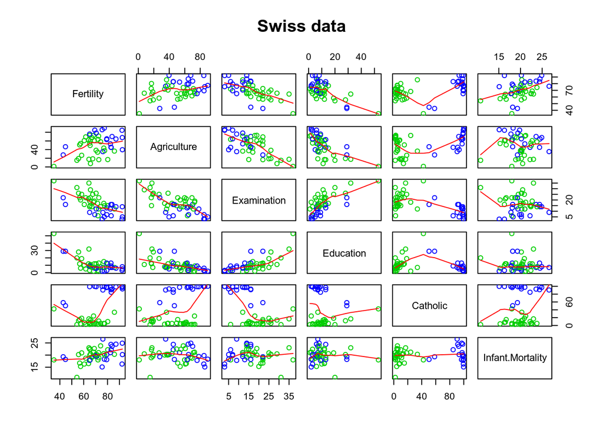

```r
pairs(swiss, panel = panel.smooth, main = "Swiss data", col = 3 + (swiss$Catholic > 50))
```

## Regressão múltipla “Go Horse”

```r
# regressão múltipla - ver estimativa ajustada de Agriculture
summary(lm(Fertility ~ . , data = swiss))$coefficients
```

```
##                    Estimate  Std. Error   t value     Pr(>|t|)
## (Intercept)      66.9151817 10.70603759  6.250229 1.906051e-07
## Agriculture      -0.1721140  0.07030392 -2.448142 1.872715e-02
## Examination      -0.2580082  0.25387820 -1.016268 3.154617e-01
## Education        -0.8709401  0.18302860 -4.758492 2.430605e-05
## Catholic          0.1041153  0.03525785  2.952969 5.190079e-03
## Infant.Mortality  1.0770481  0.38171965  2.821568 7.335715e-03
```

```r
summary(lm(Fertility ~ . , data = swiss))
```

```
##
## Call:
## lm(formula = Fertility ~ ., data = swiss)
##
## Residuals:
##      Min       1Q   Median       3Q      Max
## -15.2743  -5.2617   0.5032   4.1198  15.3213
##
## Coefficients:
##                  Estimate Std. Error t value Pr(>|t|)
## (Intercept)      66.91518   10.70604   6.250 1.91e-07 ***
## Agriculture      -0.17211    0.07030  -2.448  0.01873 *
## Examination      -0.25801    0.25388  -1.016  0.31546
## Education        -0.87094    0.18303  -4.758 2.43e-05 ***
## Catholic          0.10412    0.03526   2.953  0.00519 **
## Infant.Mortality  1.07705    0.38172   2.822  0.00734 **
## ---
## Signif. codes:  0 '***' 0.001 '**' 0.01 '*' 0.05 '.' 0.1 ' ' 1
##
## Residual standard error: 7.165 on 41 degrees of freedom
## Multiple R-squared:  0.7067, Adjusted R-squared:  0.671
## F-statistic: 19.76 on 5 and 41 DF,  p-value: 5.594e-10
```

Numa primeira análise, o coeficiente para o preditor “Examination” parece não ter relevância estatística porque seu p-value é 0.31546, e portanto $>\alpha$. Isso significa que não é possível rejeitar a Hipótese Nula $H_0$ de que o coeficiente é zero.

Vamos continuar a análise e ver o que realmente está acontecendo.

### Regressão simples apenas para “Agrigulture”

```r
# estimativa ajustada de Agriculture
agrifit = lm(Fertility ~ Agriculture, data = swiss)
summary(agrifit)$coefficients
```

```
##               Estimate Std. Error   t value     Pr(>|t|)
## (Intercept) 60.3043752 4.25125562 14.185074 3.216304e-18
## Agriculture  0.1942017 0.07671176  2.531577 1.491720e-02
```

Mmm, o sinal mudou. Quando a regressão tinha todos os campos, a relação era inversamente proporcional. Quando analisada sozinha, vira positiva. Isso faz sentido quando olhamos apenas o gráfico Fertility x Agriculture:

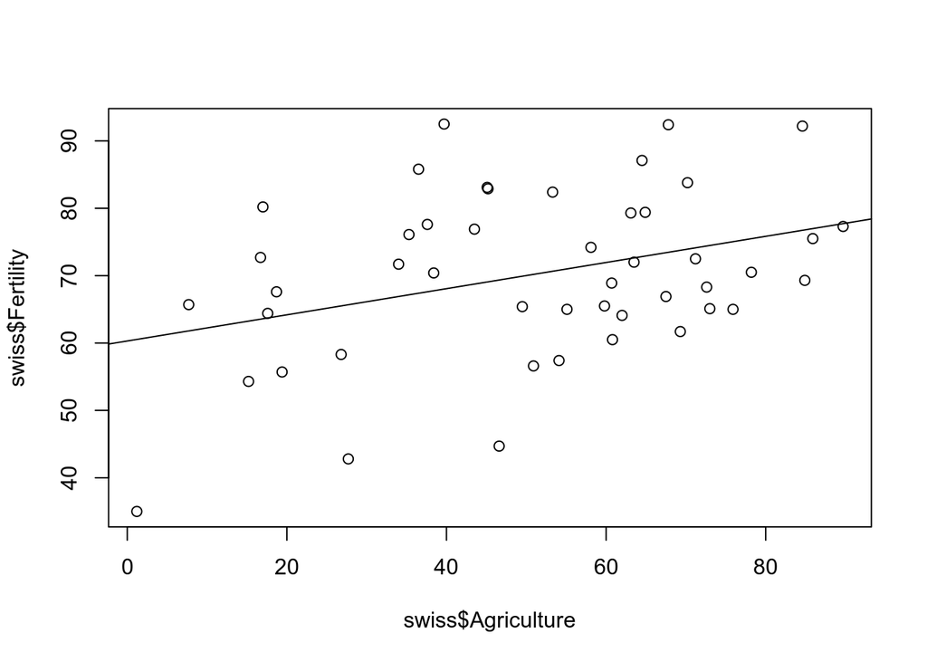

### Co-variância: Comparar “Agriculture” e “Examination”

Um dos pressupostos do modelo de regressão linear é que as variáveis preditoras sejam independentes entre si. Quando isso não acontece, distorções são introduzidas. Vamos provocar deliberadamente uma distorçao dessas:

```r
# inversao de sinal - exemplo 1
y = swiss$Fertility
x1 = swiss$Agriculture
x2 = swiss$Examination
summary(lm(y ~ x1))$coef
```

```
##               Estimate Std. Error   t value     Pr(>|t|)
## (Intercept) 60.3043752 4.25125562 14.185074 3.216304e-18
## x1           0.1942017 0.07671176  2.531577 1.491720e-02
```

```r
# Contaminar# inversao de sinal - exemplo 1
y = swiss$Fertility
x1 = swiss$Agriculture
x2 = swiss$Examination
summary(lm(y ~ x1))$coef
```

```
##               Estimate Std. Error   t value     Pr(>|t|)
## (Intercept) 60.3043752 4.25125562 14.185074 3.216304e-18
## x1           0.1942017 0.07671176  2.531577 1.491720e-02
```

```r
summary(lm(y ~ x1 + x2))$coef
```

```
##                Estimate Std. Error   t value     Pr(>|t|)
## (Intercept) 94.60968827 7.82710709 12.087440 1.413026e-15
## x1          -0.09399751 0.08590323 -1.094226 2.798103e-01
## x2          -1.19502875 0.24454695 -4.886705 1.400471e-05
```

O sinal trocou. De alguma forma, a adição da variável “Examination” ao modelo causou confusão suficiente pra inverter o sinal da relação.

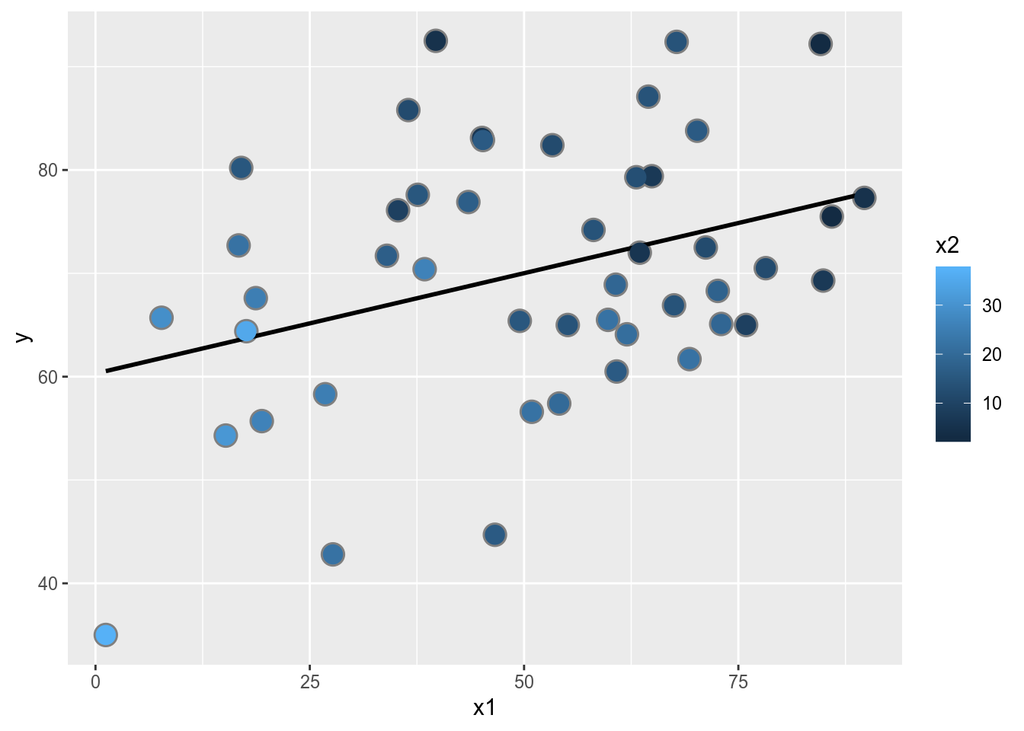

```r
library(ggplot2)
dat = data.frame(y = swiss$Fertility, x1 = swiss$Agriculture, x2 =
swiss$Examination, ey = resid(lm(y ~ x2)), ex1 = resid(lm(x1 ~ x2)))
g = ggplot(dat, aes(y = y, x = x1, colour = x2))
g = g + geom_point(colour="grey50", size = 5) + geom_smooth(method = lm,
se = FALSE, colour = "black")
g = g + geom_point(size = 4)
g
```

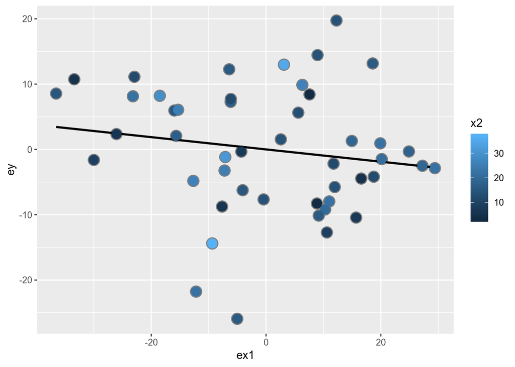

```r
g2 = ggplot(dat, aes(y = ey, x = ex1, colour = x2))
g2 = g2 + geom_point(colour="grey50", size = 5) + geom_smooth(method =
lm, se = FALSE, colour = "black") + geom_point(size = 4)
g2
```

### Outro exemplo de inversão de sinal

Neste exemplo, construímos um modelo com base em dois preditores correlacionados entre si:

- $x_2$ é uma sequência de $n$ inteiros consecutivos
- $x_1$ é uma função de $x_2$ ($x_1 = f(x_2) = 0.01 \times x_2 + g_n$, onde $g_n$ é uma distribuição uniforme de valores entre -0.1 e 0.1)
- $y$ tem distribuição normal e depende de $-x_1$ e $x_2$ (sinais opostos)

```r
# inversão de sinal - exemplo 2
n <- 100; x2 <- 1 : n; x1 <- .01 * x2 + runif(n, -.1, .1);
y = -x1 + x2 + rnorm(n, sd = .01)
```

Façamos a análise como se não soubéssemos a relação entre $y, x_1$ e $x_2$:

```r
summary(lm(y ~ x1))$coef
```

```
##              Estimate Std. Error   t value     Pr(>|t|)
## (Intercept)  3.200115   1.175893  2.721434 7.693023e-03
## x1          93.768651   2.022798 46.355919 1.809054e-68
```

Observe-se que, num modelo linear simples que tem apenas a variãvel que depende de $x_2$ (e portanto, $x_2$ está fora do modelo), o coeficiente estimado é alto e o p-value é praticamente zero.

```r
summary(lm(y ~ x1 + x2))$coef
```

```
##                 Estimate  Std. Error     t value      Pr(>|t|)
## (Intercept)  0.003838836 0.001975049    1.943666  5.483376e-02
## x1          -0.995293363 0.015846855  -62.806996  2.252038e-80
## x2           0.999910910 0.000163597 6112.036295 1.013387e-272
```

Acrescentar $x_2$ ao modelo causou uma inversão de sinal, justamente porque $y = -x_1 + x_2 + g_n$ (fizemos de conta não saber isso).

Pra facilitar a comparação, construímos um `data.frame`:

```r
dat = data.frame(y = y,
                 x1 = x1,
                 x2 = x2,
                 ey = resid(lm(y ~ x2)),  # Resíduos de y ~x_2
                 ex1 = resid(lm(x1 ~ x2)) # Aqui, os de x_1 ~ x_2, que sabemos serem relacionados
                )
```

A terceira dimensão será simulada com cores no diagrama abaixo: No eixu y, $y$; no eixo x, $x_1$ e tons de azul mais claros são valores mais altos de $x_2$:

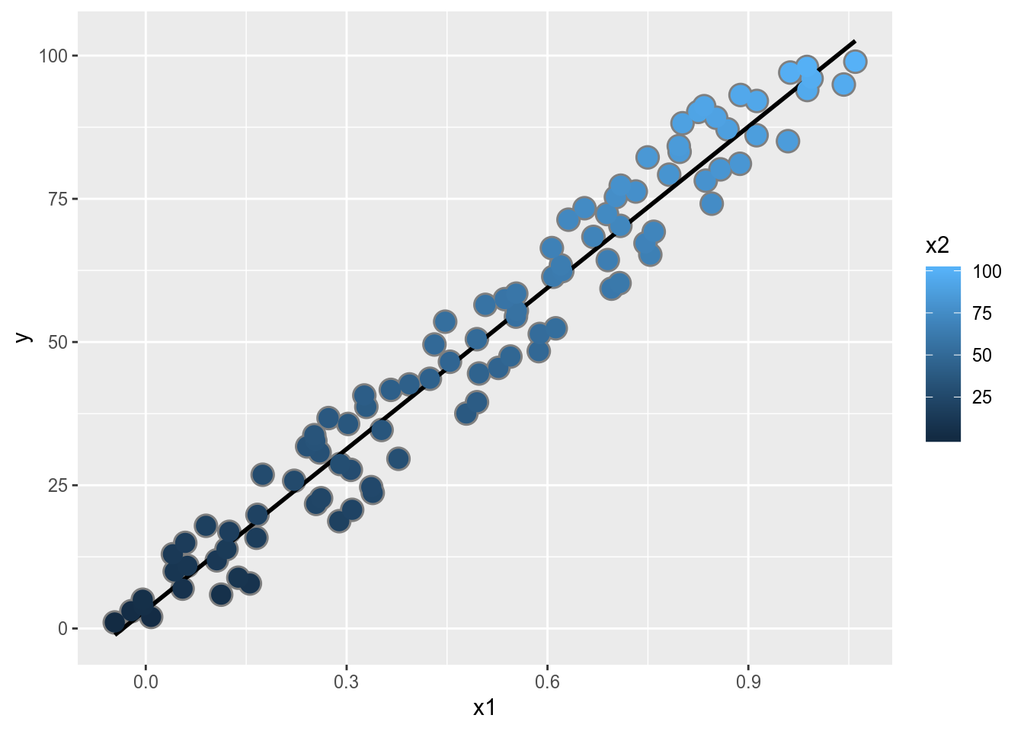

```r
g = ggplot(dat, aes(y = y, x = x1, colour = x2))
g = g + geom_point(colour="grey50", size = 5) + geom_smooth(method = lm,
se = FALSE, colour = "black")
g = g + geom_point(size = 4)
g
```

A reta preta é a do modelo linear (qual? esse ggplot está fazendo alguma mágica aí). Dá pra perceber uma forte correlação entre $x_1$ e $x_2$: há um gradiente ao longo da reta semelhante ao da própria legenda (quando $x_2 = 50, x_1 = 0.50$).

Vejamos os resíduos:

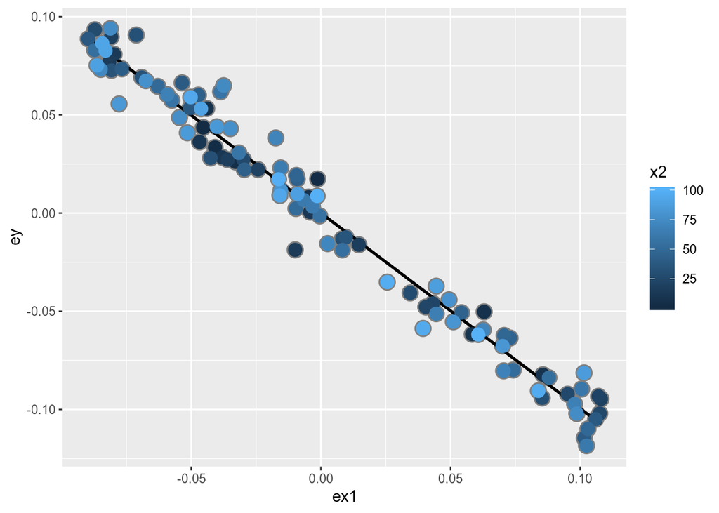

```r
g2 = ggplot(dat, aes(y = ey, x = ex1, colour = x2))
g2 = g2 + geom_point(colour="grey50", size = 5) + geom_smooth(method =
lm, se = FALSE, colour = "black") + geom_point(size = 4)
g2
```

### De volta a `swiss`

```r
# quanto o modelo explica o índice de fertilidade
summary(lm(Fertility ~ Agriculture
+ Examination
+ Education
+ Catholic
+ Infant.Mortality
, data = swiss))
```

```
##
## Call:
## lm(formula = Fertility ~ Agriculture + Examination + Education +
##     Catholic + Infant.Mortality, data = swiss)
##
## Residuals:
##      Min       1Q   Median       3Q      Max
## -15.2743  -5.2617   0.5032   4.1198  15.3213
##
## Coefficients:
##                  Estimate Std. Error t value Pr(>|t|)
## (Intercept)      66.91518   10.70604   6.250 1.91e-07 ***
## Agriculture      -0.17211    0.07030  -2.448  0.01873 *
## Examination      -0.25801    0.25388  -1.016  0.31546
## Education        -0.87094    0.18303  -4.758 2.43e-05 ***
## Catholic          0.10412    0.03526   2.953  0.00519 **
## Infant.Mortality  1.07705    0.38172   2.822  0.00734 **
## ---
## Signif. codes:  0 '***' 0.001 '**' 0.01 '*' 0.05 '.' 0.1 ' ' 1
##
## Residual standard error: 7.165 on 41 degrees of freedom
## Multiple R-squared:  0.7067, Adjusted R-squared:  0.671
## F-statistic: 19.76 on 5 and 41 DF,  p-value: 5.594e-10
```

O R² ajustado ficou em 67%. Mas é isso mesmo?

```r
# o sinal inverte com a inclusão de Examination + Education
# ambos são inversamente correlacionados com Agriculture
summary(lm(Fertility ~ Agriculture
# + Examination
# + Education
+ Catholic
+ Infant.Mortality
, data = swiss))
```

```
##
## Call:
## lm(formula = Fertility ~ Agriculture + Catholic + Infant.Mortality,
##     data = swiss)
##
## Residuals:
##      Min       1Q   Median       3Q      Max
## -25.0367  -5.6899   0.3825   5.9029  18.9091
##
## Coefficients:
##                  Estimate Std. Error t value Pr(>|t|)
## (Intercept)      26.74755   11.27417   2.372  0.02221 *
## Agriculture       0.14229    0.07253   1.962  0.05627 .
## Catholic          0.08778    0.04004   2.192  0.03383 *
## Infant.Mortality  1.63342    0.52621   3.104  0.00337 **
## ---
## Signif. codes:  0 '***' 0.001 '**' 0.01 '*' 0.05 '.' 0.1 ' ' 1
##
## Residual standard error: 10.12 on 43 degrees of freedom
## Multiple R-squared:  0.3859, Adjusted R-squared:  0.343
## F-statistic: 9.007 on 3 and 43 DF,  p-value: 9.578e-05
```

```r
cor(swiss$Agriculture, swiss$Examination)
```

```
## [1] -0.6865422
```

```r
cor(swiss$Agriculture, swiss$Education)
```

```
## [1] -0.6395225
```

```r
cor(swiss$Education, swiss$Examination)
```

```
## [1] 0.6984153
```

Agora R² ajustado é 34% sem essas variáveis de educação.

```r
# e se incluirmos uma variável desnecessária
z <- swiss$Agriculture + swiss$Education
lm(Fertility ~ . + z, data = swiss)
```

```
##
## Call:
## lm(formula = Fertility ~ . + z, data = swiss)
##
## Coefficients:
##      (Intercept)       Agriculture       Examination         Education
##          66.9152           -0.1721           -0.2580           -0.8709
##         Catholic  Infant.Mortality                 z
##           0.1041            1.0770                NA
```

Por que o coeficiente de z ficou `NA`?

```r
# o sinal inverte com a inclusão de Examination + Education
# ambos são inversamente correlacionados com Agriculture
summary(lm(Fertility ~ Agriculture
+ Examination
# + Education
+ Catholic
+ Infant.Mortality
, data = swiss))
```

```
##
## Call:
## lm(formula = Fertility ~ Agriculture + Examination + Catholic +
##     Infant.Mortality, data = swiss)
##
## Residuals:
##      Min       1Q   Median       3Q      Max
## -23.9194  -3.5530  -0.6489   6.5956  14.1767
##
## Coefficients:
##                  Estimate Std. Error t value Pr(>|t|)
## (Intercept)      59.60267   13.04246   4.570 4.25e-05 ***
## Agriculture      -0.04759    0.08032  -0.593 0.556688
## Examination      -0.96805    0.25284  -3.829 0.000423 ***
## Catholic          0.02611    0.03843   0.679 0.500551
## Infant.Mortality  1.39597    0.46259   3.018 0.004315 **
## ---
## Signif. codes:  0 '***' 0.001 '**' 0.01 '*' 0.05 '.' 0.1 ' ' 1
##
## Residual standard error: 8.82 on 42 degrees of freedom
## Multiple R-squared:  0.5448, Adjusted R-squared:  0.5014
## F-statistic: 12.57 on 4 and 42 DF,  p-value: 8.272e-07
```

```r
cor(swiss$Agriculture, swiss$Examination)
```

```
## [1] -0.6865422
```

```r
cor(swiss$Agriculture, swiss$Education)
```

```
## [1] -0.6395225
```

```r
cor(swiss$Education, swiss$Examination)
```

```
## [1] 0.6984153
```

A variável “Examination” adiciona mais ruído que “Education”, que a determina

## Fim

O ideal seria a ortogonalidade entre os preditores. Na prática, isso raramente acontece: sempre ocorre alguma inter-correlação que precisa ser analisada para ver qual (ou quais) preditor(es) precisa(m) ser eliminado(s) do modelo.

Se os resíduos tiverem a mesma correlação que os coeficientes (“same” slope) pode ser melhor pra entender do que quando há inversão de sinal, como nos exemplos acima.